# DEshort

Differential expression analysis aims at distinguish the cluster of genes that are over- or under- represented in each sample. Comparing case and control samples aims at identifying which are the genes correlated to the disease.

### 0. importing data

Import the dataframe and filter unuseful information

```r
data <- read.table("reads_gene_counts.txt",
                   header = TRUE,
                   sep = "\t")
colnames(data)
```

```
##  [1] "Geneid"     "Chr"        "Start"      "End"        "Strand"
##  [6] "Length"     "SRR7821918" "SRR7821919" "SRR7821920" "SRR7821921"
## [11] "SRR7821922" "SRR7821923" "SRR7821924" "SRR7821925" "SRR7821927"
## [16] "SRR7821937" "SRR7821938" "SRR7821939" "SRR7821940" "SRR7821941"
## [21] "SRR7821942"
```

```r
dim(data)
```

```
## [1] 78334    21
```

results in a table with 78334 obs for 21 variables (15 of which are our samples). Then, filter for the columns corresponding to the samples and ignore the rest of the information. Specifically, remove the columns containing Chr, Start, End, Strand and Length.

```r
data <- data[,-2:-6]
colnames(data)
```

```
##  [1] "Geneid"     "SRR7821918" "SRR7821919" "SRR7821920" "SRR7821921"
##  [6] "SRR7821922" "SRR7821923" "SRR7821924" "SRR7821925" "SRR7821927"
## [11] "SRR7821937" "SRR7821938" "SRR7821939" "SRR7821940" "SRR7821941"
## [16] "SRR7821942"
```

Create a matrix ready to feed into DESeq2. It has to be “numeric”.

```r
rownames(data) <- data[,1]   # set first column as row names
data <- data[ , -1]          # remove the first column
```

## 4. Exploratory data analysis (DESeq2)

Install DESeq2

```
if (!require("BiocManager", quietly = TRUE))
    install.packages("BiocManager")

BiocManager::install("DESeq2")
```

Get the sample information into a table containing the sample name and to which group it belongs.

```r
sample_info <- read.delim(
  "sample_info.txt",
  header = TRUE,
  sep = " ",
  stringsAsFactors = FALSE,
  check.names = FALSE
)
```

Now give the data to DEseq2 so that it can create a dds (DESeq Data Set that is created from the data matrix).

```r
dds <- DESeq2::DESeqDataSetFromMatrix(countData = data,
                               colData = sample_info,
                               design= ~ Group)
```

Now remove the dependence of the variance on the mean by running `DESeq2::vst()` on dds. For visualization, we typically do not want to consider the experimental groups so set `blind = TRUE`.

plot the PCA to check whether it is all right with the data and it is possible to distinguish in the 4 clusters where they belong to.

```
## using ntop=500 top features by variance
```

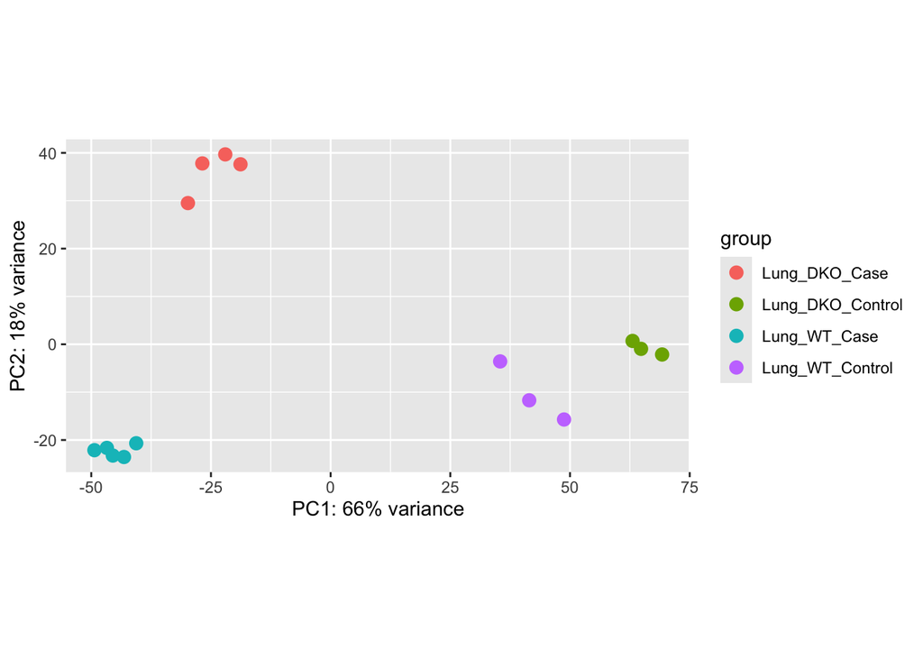

```r
# PCA using top 500 features by variance
DESeq2::plotPCA(vsd, intgroup = "Group")
```

## 5. Differential Expression analysis

```r
dss <- DESeq2::DESeq(dds)
```

```r
dss
```

```
## class: DESeqDataSet
## dim: 78334 15
## metadata(1): version
## assays(4): counts mu H cooks
## rownames(78334): ENSMUSG00000104478 ENSMUSG00000104385 ...
##   ENSMUSG00002074899 ENSMUSG00002076890
## rowData names(30): baseMean baseVar ... deviance maxCooks
## colnames(15): SRR7821918 SRR7821919 ... SRR7821941 SRR7821942
## colData names(3): Sample Group sizeFactor
```

```r
DESeq2::resultsNames(dss)
```

```
## [1] "Intercept"
## [2] "Group_Lung_DKO_Control_vs_Lung_DKO_Case"
## [3] "Group_Lung_WT_Case_vs_Lung_DKO_Case"
## [4] "Group_Lung_WT_Control_vs_Lung_DKO_Case"
```

### check resultsNames and extract the comparisons of interest

To count how many are differentially expressed, check how many are not NA in the padj column and lower than the classic 0.05 threshold.

Check the number of differentially expressed genes in each comparison with *padj < 0.05*

```r
get_results <- function(DEout, this, to_that){
  res_comp <- DESeq2::results(DEout, contrast = c("Group", this, to_that)) # extract comparison

  filt_comp <- res_comp[res_comp$padj < 0.05 & ! is.na(res_comp$padj), ] # filter for padj and remove NA

  return(filt_comp)
}

WT_Case_DKO_Case <- get_results(dss, "Lung_WT_Case", "Lung_DKO_Case") # WT cases against DKO cases
WT_Control_WT_Case <- get_results(dss, "Lung_WT_Control", "Lung_WT_Case") # WT control against WT case
DKO_Control_DKO_Case <- get_results(dss, "Lung_DKO_Control", "Lung_DKO_Case") # DKO control against DKO case
```

### Heatmap

Produce heatmaps to visualize the differences in the expression between groups.

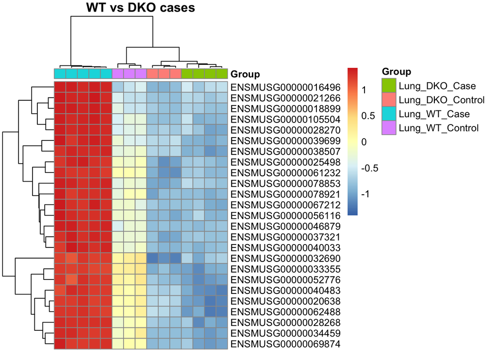

```r
# 1. Extract VSD matrix
vsd_mat <- SummarizedExperiment::assay(vsd)

heatplot <- function(comparison, samples, vsd, title, leg = TRUE){
  # 2. Select significant genes for the comparison
  filtered <- comparison[(comparison$log2FoldChange > 1 | comparison$log2FoldChange < -1), ] # | log2FC | > 1 filtering
  filtered <- filtered[order(filtered$padj),] # increasing order adjusted p-val
  filtered <- filtered[1:25,] # select the first 25 entries
  heat_matrix <- vsd[rownames(filtered),] # obtain a DESeq object matrix by filtering the VST result object

  # 3. Build annotation data frame for the comparison
  ann <- samples[, "Group", drop = FALSE] # extract Group column for the samples information
  rownames(ann) <- samples$Sample # index ann based on the samples

  # 4. Plot heatmap
  library(pheatmap)
  pheatmap(heat_matrix,
           annotation_col = ann,
           show_rownames = TRUE,
           fontsize_col = 10,
           clustering_distance_rows = "euclidean",
           clustering_distance_cols = "euclidean",
           clustering_method = "complete",
           scale = "row",
           main = title,
           annotation_legend = leg,
           show_colnames = FALSE)
}

heatplot(WT_Case_DKO_Case, sample_info, vsd_mat, title = "WT vs DKO cases")
```

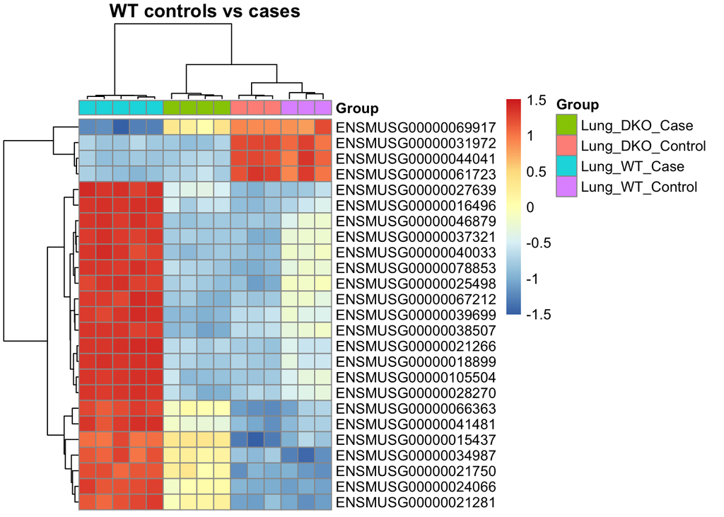

```r
heatplot(WT_Control_WT_Case, sample_info, vsd_mat, title = "WT controls vs cases")
```

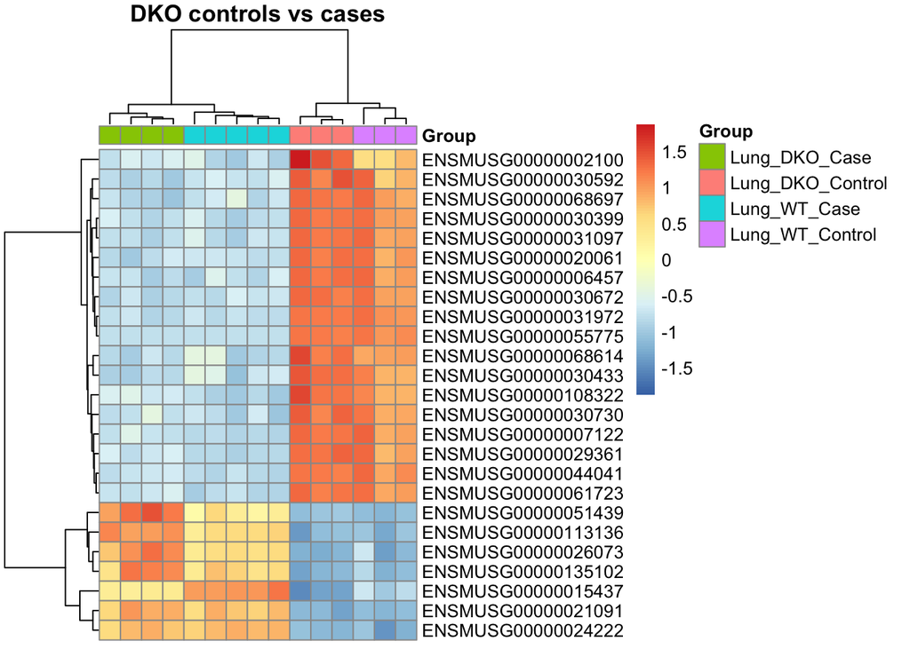

```r
heatplot(DKO_Control_DKO_Case, sample_info, vsd_mat, title = "DKO controls vs cases")
```

**SUMMARY REPORT TABLE 1**

#### 1. How many genes are differentially expressed (DE) in the pairwise comparisons you selected (e.g. padj < 0.05)?

```r
paste0("There has been found ", nrow(WT_Case_DKO_Case), " DE genes in WT vs DKO case comparison having padj < 0.05.")
```

```
## [1] "There has been found 7976 DE genes in WT vs DKO case comparison having padj < 0.05."
```

```r
paste0("There has been found ", nrow(WT_Case_DKO_Case[which(WT_Case_DKO_Case$log2FoldChange > 1 | WT_Case_DKO_Case$log2FoldChange < -1), ]), " DE genes in WT vs DKO case comparison having padj < 0.05 and | log2FC | > 1.")
```

```
## [1] "There has been found 3972 DE genes in WT vs DKO case comparison having padj < 0.05 and | log2FC | > 1."
```

```r
paste0("There has been found ", nrow(WT_Control_WT_Case), " DE genes in WT control vs case comparison having padj < 0.05.")
```

```
## [1] "There has been found 11055 DE genes in WT control vs case comparison having padj < 0.05."
```

```r
paste0("There has been found ", nrow(WT_Control_WT_Case[which(WT_Control_WT_Case$log2FoldChange > 1 | WT_Control_WT_Case$log2FoldChange < -1), ]), " DE genes in WT control vs case comparison having padj < 0.05 and | log2FC | > 1.")
```

```
## [1] "There has been found 6766 DE genes in WT control vs case comparison having padj < 0.05 and | log2FC | > 1."
```

```r
paste0("There has been found ", nrow(DKO_Control_DKO_Case), " DE genes in DKO control vs case comparison having padj < 0.05.")
```

```
## [1] "There has been found 11405 DE genes in DKO control vs case comparison having padj < 0.05."
```

```r
paste0("There has been found ", nrow(DKO_Control_DKO_Case[which(DKO_Control_DKO_Case$log2FoldChange > 1 | DKO_Control_DKO_Case$log2FoldChange < -1), ]), " DE genes in DKO control vs case comparison having padj < 0.05 and | log2FC | > 1.")
```

```
## [1] "There has been found 6785 DE genes in DKO control vs case comparison having padj < 0.05 and | log2FC | > 1."
```

#### 2. How many of the DE genes are up-regulated vs down-regulated meaningfully (padj < 0.05)?

```r
paste0("For WT vs DKO case are ", sum(WT_Case_DKO_Case$log2FoldChange > 1), " upregulated and ", length(WT_Case_DKO_Case$log2FoldChange) - sum(WT_Case_DKO_Case$log2FoldChange > -1), " downregulated.")
```

```
## [1] "For WT vs DKO case are 1909 upregulated and 2063 downregulated."
```

```r
paste0("For WT controls vs cases are ", sum(WT_Control_WT_Case$log2FoldChange > 1), " upregulated and ", length(WT_Control_WT_Case$log2FoldChange) - sum(WT_Control_WT_Case$log2FoldChange > -1), " downregulated.")
```

```
## [1] "For WT controls vs cases are 3961 upregulated and 2805 downregulated."
```

```r
paste0("For DKO control vs case are ", sum(DKO_Control_DKO_Case$log2FoldChange > 1), " upregulated and ", length(DKO_Control_DKO_Case$log2FoldChange) - sum(DKO_Control_DKO_Case$log2FoldChange > -1), " downregulated.")
```

```
## [1] "For DKO control vs case are 3874 upregulated and 2911 downregulated."
```

#### 3. Based on the original publication, select 2-3 genes that are of particular interest and investigate their expression level.

```r
# Install database
if (!require("org.Mm.eg.db", quietly = TRUE))
  BiocManager::install("org.Mm.eg.db")

library(org.Mm.eg.db)
library(AnnotationDbi)

# function to obtain ENSEMBL names from their name
gfilter <- function(symbols, dss){
  ens_ids <- mapIds(
    org.Mm.eg.db,
    keys      = symbols,
    column    = "ENSEMBL",
    keytype   = "SYMBOL",
    multiVals = "first"
  )

  dss_fil <- dss[grepl(paste(unname(ens_ids), collapse="|"), row.names(dss), ignore.case = TRUE), ]

  # add gene name to the data frame
  gene_map_one <- data.frame(
    ENSEMBL = unname(ens_ids),
    name    = names(ens_ids),
    stringsAsFactors = FALSE
  )

  dss_fil$name <- gene_map_one$name[match(rownames(dss_fil), gene_map_one$ENSEMBL)]

  return(dss_fil)
}

# list of gene names to convert into ENSEMBLE codes
## L5 (type I IFN)
symbols <- c(
  "Ifnb1", "Ifit1", "Ifit3", "Oas1a", "Oas2", "Oas3", "Oasl1", "Oasl2", "Mx1", "Stat2", "Irf7", "Irf9"
)

Case_typeI <- gfilter(symbols, WT_Case_DKO_Case)
WT_typeI <- gfilter(symbols, WT_Control_WT_Case)
DKO_typeI <- gfilter(symbols, DKO_Control_DKO_Case)


## L7 (type II IFN)
symbols <- c(
  "Ifng", "Irf1", "Irf2", "Irf8", "Il12rb1", "Il12rb2", "Tap1", "Tap2", "Gbp2", "Gbp3", "Gbp4", "Gbp5", "Gbp6", "Gbp8", "Gbp9", "Gbp10", "Gbp11"
)

Case_typeII <- gfilter(symbols, WT_Case_DKO_Case)
WT_typeII <- gfilter(symbols, WT_Control_WT_Case)
DKO_typeII <- gfilter(symbols, DKO_Control_DKO_Case)
```

```
common <- rownames(WT_typeII)[which(! rownames(WT_typeII) %in% rownames(DKO_typeII))]

DKO_typeI[which(rownames(DKO_typeI) == "ENSMUSG00000052776"),]
```

After comparing the DE genes in the three different comparisons, I choose four representative ones from different BP families that explain best what has been concluded in the paper.

Take the vsd information on the corrected variance and plot those

```r
# Define genes of interest
gene_annot <- data.frame(
  Gene = c(
    "ENSMUSG00000052776",
    "ENSMUSG00000034459",
    "ENSMUSG00000105504",
    "ENSMUSG00000018899"
  ),
  Label = c(
    "Oas1a (type I)\nENSMUSG00000052776",
    "Ifit1 (type I)\nENSMUSG00000034459",
    "Gbp5 (type II)\nENSMUSG00000105504",
    "Irf1 (type II)\nENSMUSG00000018899"
  )
)

# Extract expression data for selected genes from vsd_mat
genes_of_interest <- gene_annot$Gene
vsd_subset <- vsd_mat[genes_of_interest, ]

# Convert to data frame and add Gene column
df_wide <- as.data.frame(t(vsd_subset))
df_wide$Sample <- rownames(df_wide)

# Reshape to long format
library(tidyr)
library(dplyr)

df_long <- df_wide %>%
  pivot_longer(cols = -Sample, names_to = "Gene", values_to = "Expression") %>%
  left_join(sample_info, by = "Sample") %>%
  left_join(gene_annot, by = "Gene")

# Convert Label to a factor with the specific order
df_long$Label <- factor(df_long$Label, levels = c(
  "Oas1a (type I)\nENSMUSG00000052776",
  "Ifit1 (type I)\nENSMUSG00000034459",
  "Gbp5 (type II)\nENSMUSG00000105504",
  "Irf1 (type II)\nENSMUSG00000018899"
))
```

Now plot the filtered table

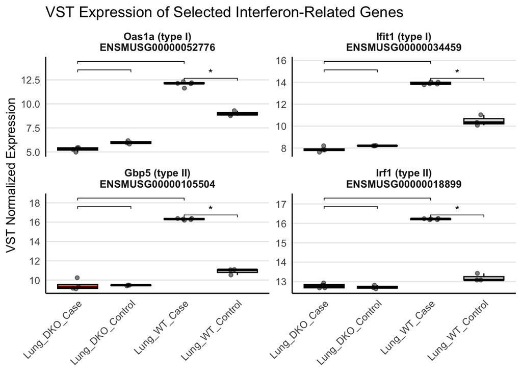

```r
# Define comparisons for statistical testing
comparisons <- list(
  c("Lung_WT_Control", "Lung_WT_Case"),
  c("Lung_DKO_Control", "Lung_DKO_Case"),
  c("Lung_WT_Case", "Lung_DKO_Case")
)

library(ggplot2)
library(ggpubr)

# These colors help distinguish between WT and DKO groups clearly [1, 2]
group_colors <- c(
  "Lung_WT_Control"  = "#CCCCCC", # Light Grey
  "Lung_WT_Case"     = "#00008B", # Dark Blue
  "Lung_DKO_Control" = "#FFD700", # Gold/Yellow
  "Lung_DKO_Case"    = "#FF4500"  # Orange-Red
)

# 2. Updated Plotting Code
ggplot(df_long, aes(x = Group, y = Expression, fill = Group)) +
  # Add transparency (alpha) to the boxplot to make it look cleaner
  geom_boxplot(outlier.shape = NA, alpha = 0.7, color = "black") +
  # Increase jitter transparency to avoid clutter while showing every replicate [5]
  geom_jitter(width = 0.15, size = 1.5, alpha = 0.5) +

  # Maintain your factor-based ordering for Oas1a, Ifit1, Gbp5, and Irf1 [6, 7]
  facet_wrap(~ Label, scales = "free_y") +

  stat_compare_means(
    comparisons = comparisons,
    method = "wilcox.test",
    label = "p.signif",
    hide.ns = TRUE,
    step.increase = 0.12 # Prevents p-value labels from overlapping
  ) +

  # Switch to theme_minimal
  theme_minimal(base_size = 12) +
  theme(
    # Remove the grey boxes behind the gene names
    strip.background = element_blank(),
    strip.text = element_text(face = "bold", size = 10),

    # Clean up the axes and remove background clutter
    panel.grid.minor = element_blank(),
    panel.grid.major.x = element_blank(),
    axis.line = element_line(color = "black"),
    axis.text.x = element_text(angle = 45, hjust = 1),

    legend.position = "none" # Groups are already labeled on the X-axis
  ) +

  # Apply the custom color scale
  scale_fill_manual(values = group_colors) +

  labs(
    title = "VST Expression of Selected Interferon-Related Genes",
    y = "VST Normalized Expression",
    x = NULL
  )
```

## 6. Overrepresentation analysis

**Hypergeometric test** is used to check overrepresentation for each biological pathways (BP).

Install clusterProfiler

```r
if (!require("BiocManager", quietly = TRUE))
  install.packages("BiocManager")

if (!require("clusterProfiler", quietly = TRUE))
  BiocManager::install("clusterProfiler")
# the link to enrichplot is broken in bioconductor, install directly
if (!require("enrichplot", quietly = TRUE))
  BiocManager::install("enrichplot", force = TRUE)
# without updating the other packages (might create problems with dependencies)

library("clusterProfiler")
```

Download Bioconductor package with genome wide annotation for your species

```r
if (!require("org.Mm.eg.db", quietly = TRUE))
  BiocManager::install("org.Mm.eg.db")

library("org.Mm.eg.db")
```

Call and plot enrichGO

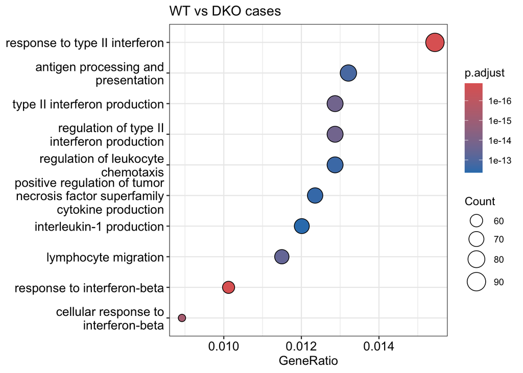

```r
# Select significant genes WT control and cases and run the enrichment via Gene Ontology
ego_gen <- function(comparison, DEresults){
  ego <- clusterProfiler::enrichGO(
    gene = rownames(comparison),
    universe = rownames(DEresults),
    OrgDb = org.Mm.eg.db,
    ont = "BP",
    keyType = "ENSEMBL",
    maxGSSize = 150,
    pvalueCutoff = 0.05
    )

  # filter for genes with log2FC higher than +/- 1 (2x DE)
  ego@result <- ego@result[which(-1 > ego@result$FoldEnrichment | 1 < ego@result$FoldEnrichment), ]

  return(ego)
}

ego_WT <- ego_gen(WT_Control_WT_Case, dss)
ego_DKO <- ego_gen(DKO_Control_DKO_Case, dss)
ego_Case <- ego_gen(WT_Case_DKO_Case, dss)

# plotting the results
dotplot(ego_Case, title="WT vs DKO cases")
```

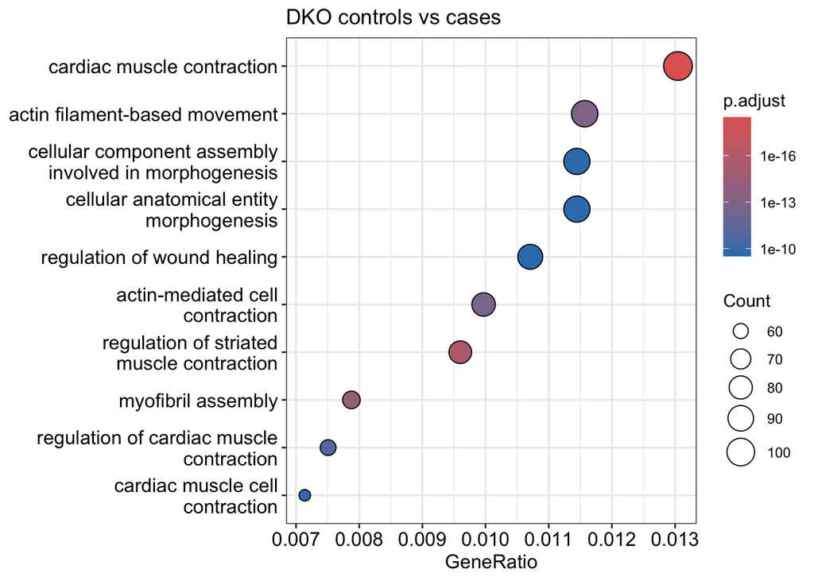

```r
dotplot(ego_DKO, title="DKO controls vs cases")
```

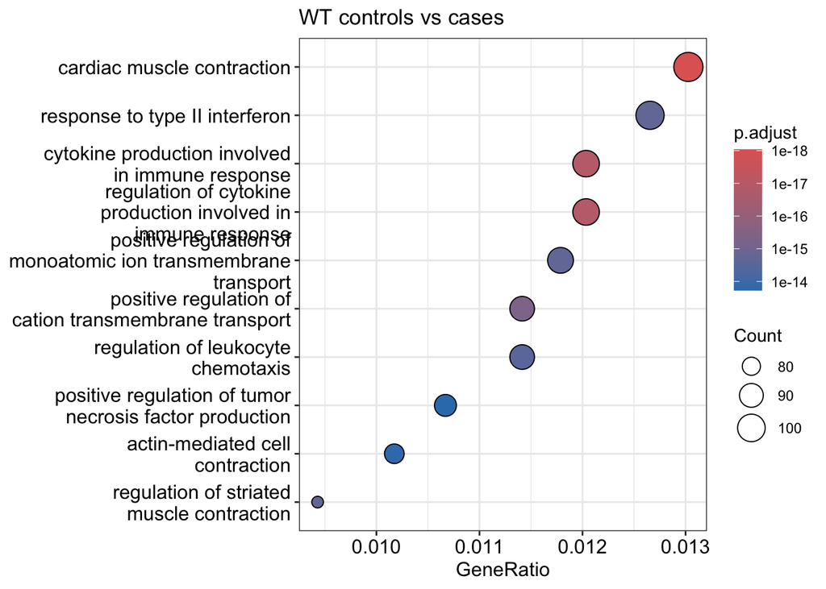

```r
dotplot(ego_WT, title="WT controls vs cases")
```

- *gene = sig*

  sig should be a vector of ENSEMBL gene IDs that are significantly DE.
- *universe = rownames(mat)*

  All genes measured in the experiment. Since mat is your DESeq2 input matrix, its row names are all ENSEMBL IDs → perfect universe.
- *OrgDb = org.Mm.eg.db*

  Genome-wide mouse annotation package from Bioconductor.
- *ont = “BP”* or “MF”, “CC”, or “ALL”

  GO subontology:
  - BP: Biological Process
  - MF: Molecular Function
  - CC: Cellular Component
- *keyType = “ENSEMBL”*

  Because the gene IDs (row names) are ENSEMBL IDs like “ENSMUSG00000000001”.
- *maxGSSize = 150* maximal size of genes annotated for testing